# Kerri Anderson

Load Modeling AI/ML GreatLearning Project 3 July 2021

This project is focused on helping a bank grow its loan (asset) business. We will use information from last year's campaign to identify which customers are likely to puchase a personal loan and will work to target them with marketing strategies. Following initial data exploration, a logistic regression model and decision tree will be built and compared on the test dataset for performance.

Please note, some of the coding for this program is taken from class material such as the lecture, case studies, or mentored learning sessions. No other sources were used for code blocks.

## Load packages

```python
%matplotlib inline

# Library to suppress warnings or deprecation notes
import warnings

warnings.filterwarnings("ignore")

# Libraries to help with reading and manipulating data

import pandas as pd
import numpy as np

# Library to split data
from sklearn.model_selection import train_test_split

# libaries to help with data visualization
import matplotlib.pyplot as plt
import seaborn as sns

# Removes the limit for the number of displayed columns
pd.set_option("display.max_columns", None)
# Sets the limit for the number of displayed rows
pd.set_option("display.max_rows", 200)

# Libraries to build decision tree classifier
from sklearn.tree import DecisionTreeClassifier
from sklearn import tree


# To tune different models
from sklearn.model_selection import GridSearchCV

# To get diferent metric scores
from sklearn.metrics import (
    f1_score,
    accuracy_score,
    recall_score,
    precision_score,
    confusion_matrix,
    plot_confusion_matrix,
    make_scorer,
)

# To build model for prediction

from sklearn.linear_model import LogisticRegression


from sklearn import metrics
```

## Import dataset

```python
loan = "loan_modelling.csv"
loandata = pd.read_csv(loan)
```

# Initial data exploration

```python
#look at the first 10 rows of data
loandata.head(10)
```

|  | ID | Age | Experience | Income | ZIPCode | Family | CCAvg | Education | Mortgage | Personal_Loan | Securities_Account | CD_Account | Online | CreditCard |
| --- | --- | --- | --- | --- | --- | --- | --- | --- | --- | --- | --- | --- | --- | --- |
| 0 | 1 | 25 | 1 | 49 | 91107 | 4 | 1.6 | 1 | 0 | 0 | 1 | 0 | 0 | 0 |
| 1 | 2 | 45 | 19 | 34 | 90089 | 3 | 1.5 | 1 | 0 | 0 | 1 | 0 | 0 | 0 |
| 2 | 3 | 39 | 15 | 11 | 94720 | 1 | 1.0 | 1 | 0 | 0 | 0 | 0 | 0 | 0 |
| 3 | 4 | 35 | 9 | 100 | 94112 | 1 | 2.7 | 2 | 0 | 0 | 0 | 0 | 0 | 0 |
| 4 | 5 | 35 | 8 | 45 | 91330 | 4 | 1.0 | 2 | 0 | 0 | 0 | 0 | 0 | 1 |
| 5 | 6 | 37 | 13 | 29 | 92121 | 4 | 0.4 | 2 | 155 | 0 | 0 | 0 | 1 | 0 |
| 6 | 7 | 53 | 27 | 72 | 91711 | 2 | 1.5 | 2 | 0 | 0 | 0 | 0 | 1 | 0 |
| 7 | 8 | 50 | 24 | 22 | 93943 | 1 | 0.3 | 3 | 0 | 0 | 0 | 0 | 0 | 1 |
| 8 | 9 | 35 | 10 | 81 | 90089 | 3 | 0.6 | 2 | 104 | 0 | 0 | 0 | 1 | 0 |
| 9 | 10 | 34 | 9 | 180 | 93023 | 1 | 8.9 | 3 | 0 | 1 | 0 | 0 | 0 | 0 |

First 10 rows of data seem reasonable - will need to look at all values to confirm if values of each variable are reasonable

```python
loandata.shape # Check number of columns and rows in data frame
```

```
(5000, 14)
```

There are 5000 rows and 14 columns of data

```python
loandata.isnull().values.any() # check if there are any null values in data set
```

```
False
```

There are no null values, but we still need to determine if all values of the variables are reasonable and within the expected range

```python
# what data types are in the dataset
loandata.info()
```

```
<class 'pandas.core.frame.DataFrame'>
RangeIndex: 5000 entries, 0 to 4999
Data columns (total 14 columns):
 #   Column              Non-Null Count  Dtype
---  ------              --------------  -----
 0   ID                  5000 non-null   int64
 1   Age                 5000 non-null   int64
 2   Experience          5000 non-null   int64
 3   Income              5000 non-null   int64
 4   ZIPCode             5000 non-null   int64
 5   Family              5000 non-null   int64
 6   CCAvg               5000 non-null   float64
 7   Education           5000 non-null   int64
 8   Mortgage            5000 non-null   int64
 9   Personal_Loan       5000 non-null   int64
 10  Securities_Account  5000 non-null   int64
 11  CD_Account          5000 non-null   int64
 12  Online              5000 non-null   int64
 13  CreditCard          5000 non-null   int64
dtypes: float64(1), int64(13)
memory usage: 547.0 KB
```

Data types are all numeric - we can look at the distribution of values for each variable

The ID variable is used for unique row identification and will not be used for analysis

```python
#as all of the values are numeric, the describe() feature can be used as a good tool for initial data exploration
loandata.describe().T
```

|  | count | mean | std | min | 25% | 50% | 75% | max |
| --- | --- | --- | --- | --- | --- | --- | --- | --- |
| ID | 5000.0 | 2500.500000 | 1443.520003 | 1.0 | 1250.75 | 2500.5 | 3750.25 | 5000.0 |
| Age | 5000.0 | 45.338400 | 11.463166 | 23.0 | 35.00 | 45.0 | 55.00 | 67.0 |
| Experience | 5000.0 | 20.104600 | 11.467954 | -3.0 | 10.00 | 20.0 | 30.00 | 43.0 |
| Income | 5000.0 | 73.774200 | 46.033729 | 8.0 | 39.00 | 64.0 | 98.00 | 224.0 |
| ZIPCode | 5000.0 | 93169.257000 | 1759.455086 | 90005.0 | 91911.00 | 93437.0 | 94608.00 | 96651.0 |
| Family | 5000.0 | 2.396400 | 1.147663 | 1.0 | 1.00 | 2.0 | 3.00 | 4.0 |
| CCAvg | 5000.0 | 1.937938 | 1.747659 | 0.0 | 0.70 | 1.5 | 2.50 | 10.0 |
| Education | 5000.0 | 1.881000 | 0.839869 | 1.0 | 1.00 | 2.0 | 3.00 | 3.0 |
| Mortgage | 5000.0 | 56.498800 | 101.713802 | 0.0 | 0.00 | 0.0 | 101.00 | 635.0 |
| Personal_Loan | 5000.0 | 0.096000 | 0.294621 | 0.0 | 0.00 | 0.0 | 0.00 | 1.0 |
| Securities_Account | 5000.0 | 0.104400 | 0.305809 | 0.0 | 0.00 | 0.0 | 0.00 | 1.0 |
| CD_Account | 5000.0 | 0.060400 | 0.238250 | 0.0 | 0.00 | 0.0 | 0.00 | 1.0 |
| Online | 5000.0 | 0.596800 | 0.490589 | 0.0 | 0.00 | 1.0 | 1.00 | 1.0 |
| CreditCard | 5000.0 | 0.294000 | 0.455637 | 0.0 | 0.00 | 0.0 | 1.00 | 1.0 |

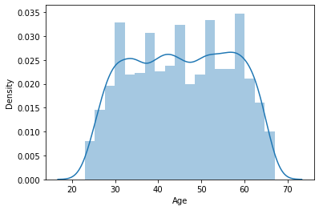

```python
#distribtuion of age
sns.distplot(loandata['Age'])
```

age range is reasonable - no extreme outliers - mean and median are close so there is not a great amount of skew in the data

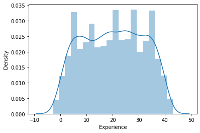

```python
#distribtuion of experience (years of professional working experience)
sns.distplot(loandata['Experience'])
```

Years of working experience sould not be <0 Any value <0 should be converted to 0 Otherwise the values seem reasonable

```python
#if experience is <0 then convert to values of 0
loandata['Experience'][loandata['Experience']<0]=0
```

```python
#confirm the transformation worked as expected
loandata.describe()
```

|  | ID | Age | Experience | Income | ZIPCode | Family | CCAvg | Education | Mortgage | Personal_Loan | Securities_Account | CD_Account | Online | CreditCard |
| --- | --- | --- | --- | --- | --- | --- | --- | --- | --- | --- | --- | --- | --- | --- |
| count | 5000.000000 | 5000.000000 | 5000.000000 | 5000.000000 | 5000.000000 | 5000.000000 | 5000.000000 | 5000.000000 | 5000.000000 | 5000.000000 | 5000.000000 | 5000.00000 | 5000.000000 | 5000.000000 |
| mean | 2500.500000 | 45.338400 | 20.119600 | 73.774200 | 93169.257000 | 2.396400 | 1.937938 | 1.881000 | 56.498800 | 0.096000 | 0.104400 | 0.06040 | 0.596800 | 0.294000 |
| std | 1443.520003 | 11.463166 | 11.440484 | 46.033729 | 1759.455086 | 1.147663 | 1.747659 | 0.839869 | 101.713802 | 0.294621 | 0.305809 | 0.23825 | 0.490589 | 0.455637 |
| min | 1.000000 | 23.000000 | 0.000000 | 8.000000 | 90005.000000 | 1.000000 | 0.000000 | 1.000000 | 0.000000 | 0.000000 | 0.000000 | 0.00000 | 0.000000 | 0.000000 |
| 25% | 1250.750000 | 35.000000 | 10.000000 | 39.000000 | 91911.000000 | 1.000000 | 0.700000 | 1.000000 | 0.000000 | 0.000000 | 0.000000 | 0.00000 | 0.000000 | 0.000000 |
| 50% | 2500.500000 | 45.000000 | 20.000000 | 64.000000 | 93437.000000 | 2.000000 | 1.500000 | 2.000000 | 0.000000 | 0.000000 | 0.000000 | 0.00000 | 1.000000 | 0.000000 |
| 75% | 3750.250000 | 55.000000 | 30.000000 | 98.000000 | 94608.000000 | 3.000000 | 2.500000 | 3.000000 | 101.000000 | 0.000000 | 0.000000 | 0.00000 | 1.000000 | 1.000000 |
| max | 5000.000000 | 67.000000 | 43.000000 | 224.000000 | 96651.000000 | 4.000000 | 10.000000 | 3.000000 | 635.000000 | 1.000000 | 1.000000 | 1.00000 | 1.000000 | 1.000000 |

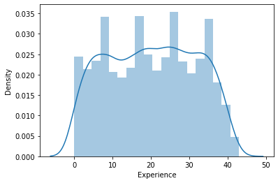

```python
#review distribution of experience following transformation
sns.distplot(loandata['Experience'])
```

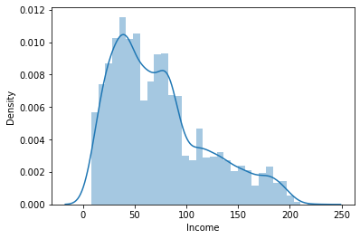

```python
#distribtuion of income
sns.distplot(loandata['Income'])
```

```python
#look at distribution of log transoformation of Income variable
#loandata['Income_log']=np.log(loandata['Income'])
#sns.distplot(loandata['Income_log'])
```

Income is right-skewed given that a few incomes are very high and the majority tend to be more to the left.

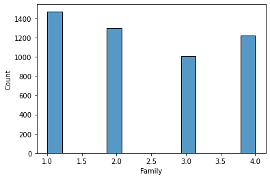

```python
#look at histogram of family size
sns.histplot(loandata['Family'])
```

```python
# function to create labeled barplots


def labeled_barplot(data, feature, perc=False, n=None):
    """
    Barplot with percentage at the top

    data: dataframe
    feature: dataframe column
    perc: whether to display percentages instead of count (default is False)
    n: displays the top n category levels (default is None, i.e., display all levels)
    """

    total = len(data[feature])  # length of the column
    count = data[feature].nunique()
    if n is None:
        plt.figure(figsize=(count + 1, 5))
    else:
        plt.figure(figsize=(n + 1, 5))

    plt.xticks(rotation=90, fontsize=15)
    ax = sns.countplot(
        data=data,
        x=feature,
        palette="Paired",
        order=data[feature].value_counts().index[:n].sort_values(),
    )

    for p in ax.patches:
        if perc == True:
            label = "{:.1f}%".format(
                100 * p.get_height() / total
            )  # percentage of each class of the category
        else:
            label = p.get_height()  # count of each level of the category

        x = p.get_x() + p.get_width() / 2  # width of the plot
        y = p.get_height()  # height of the plot

        ax.annotate(
            label,
            (x, y),
            ha="center",
            va="center",
            size=12,
            xytext=(0, 5),
            textcoords="offset points",
        )  # annotate the percentage

    plt.show()  # show the plot
```

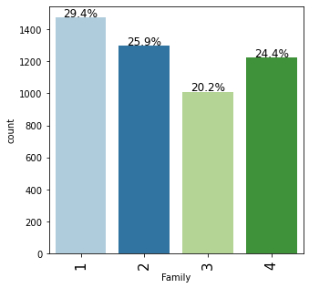

```python
labeled_barplot(loandata, "Family", perc=True)
```

Family size has values of whole numbers which is good No values of zero, <0 or incremental which gives confidence in the data. It is somewhat surprising that the value only goes up to 4. If this information was collected through self-report it's likely that the value of 4 represents values >=4.

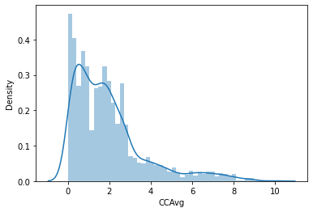

```python
#average credit card spending per month
sns.distplot(loandata['CCAvg'])
```

Average credit card spending per month seems to be right-skewed, similar to income. We will further evaluate the relationship between cc spending and income (as well as other variables) in bivariate analysis

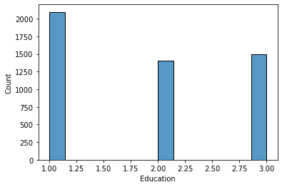

```python
#histogram of education levels
sns.histplot(loandata['Education'])
```

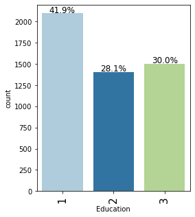

```python
labeled_barplot(loandata, "Education", perc=True)
```

The values for the Education variable are as expected. No values of zero, <0, or fractions. This gives confidence in the data. 1: Undergrad; 2: Graduate;3: Advanced/Professional. More people have an undergraduate degree than graduate or advanced degree.

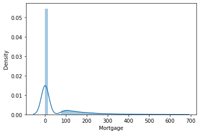

```python
#distribution of mortgate amounts
sns.distplot(loandata['Mortgage'])
```

This is an interesting distribution. Mortgage value of 0 could indicate renting, owning a home outright, or perhaps they have a mortgage through a different company. We could create a mortgage indicator to simplify this data.

```python
#create mortgage indicator
loandata["Mortgage_ind"]= np.where(loandata["Mortgage"]==0,0,1)
```

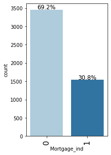

```python
labeled_barplot(loandata, "Mortgage_ind", perc=True)
```

```python
loandata.tail()
```

|  | ID | Age | Experience | Income | ZIPCode | Family | CCAvg | Education | Mortgage | Personal_Loan | Securities_Account | CD_Account | Online | CreditCard | Mortgage_ind |
| --- | --- | --- | --- | --- | --- | --- | --- | --- | --- | --- | --- | --- | --- | --- | --- |
| 4995 | 4996 | 29 | 3 | 40 | 92697 | 1 | 1.9 | 3 | 0 | 0 | 0 | 0 | 1 | 0 | 0 |
| 4996 | 4997 | 30 | 4 | 15 | 92037 | 4 | 0.4 | 1 | 85 | 0 | 0 | 0 | 1 | 0 | 1 |
| 4997 | 4998 | 63 | 39 | 24 | 93023 | 2 | 0.3 | 3 | 0 | 0 | 0 | 0 | 0 | 0 | 0 |
| 4998 | 4999 | 65 | 40 | 49 | 90034 | 3 | 0.5 | 2 | 0 | 0 | 0 | 0 | 1 | 0 | 0 |
| 4999 | 5000 | 28 | 4 | 83 | 92612 | 3 | 0.8 | 1 | 0 | 0 | 0 | 0 | 1 | 1 | 0 |

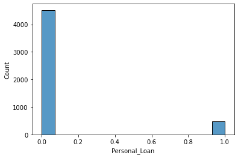

```python
#histogram of target variable
sns.histplot(loandata['Personal_Loan'])
```

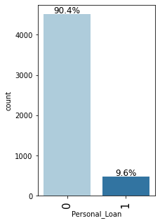

```python
labeled_barplot(loandata, "Personal_Loan", perc=True)
```

This is an indicator variable that represents our target outcome. 1 indicates that the client took out a personal loan. We want to learn more about the type of customer who is likely to take out a loan and target them to help support growth of the bank's asset customer base.

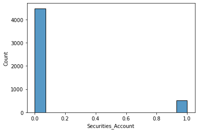

```python
#histogram of securities indicator
sns.histplot(loandata['Securities_Account'])
```

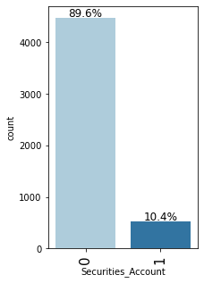

```python
labeled_barplot(loandata, "Securities_Account", perc=True)
```

Indicator for if the customer has a securities account with this bank. this is an investment account.Very few customers have a securities account.

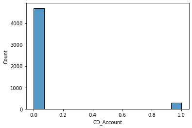

```python
#histogram of CD indicator
sns.histplot(loandata['CD_Account'])
```

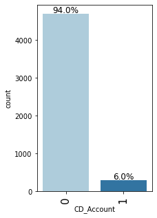

```python
labeled_barplot(loandata, "CD_Account", perc=True)
```

Indicator for if the customer has a CD account with the bank.This is a long-term savings account. It may be beneficial to group the account indicators. Very few customers have a CD account.

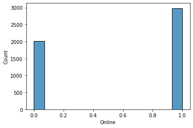

```python
#inciator for online banking
sns.histplot(loandata['Online'])
```

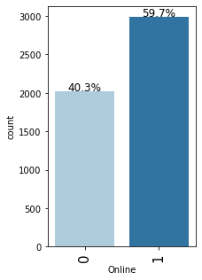

```python
labeled_barplot(loandata, "Online", perc=True)
```

Indicator for if the customer uses online banking tools. The majority of customers do use online banking tools.

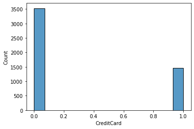

```python
#inciator of credit card with a different bank
sns.histplot(loandata['CreditCard'])
```

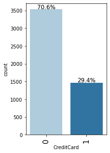

```python
labeled_barplot(loandata, "CreditCard", perc=True)
```

# Initial data exploration conclusions

Upon initial exploration, the values for the data seem reasonable without the need for much data cleansing.

It would be beneficial to explore the bivariate distributions of the data.

It would be beneficial to create a debt:income ratio to evaluate the correlation with the outcome variable.

It would be beneficial to create a combined indicator for the CD and securities accounts to see if it is associated more strongly with the target outcome.

```python
#create an estimated debt:income ratio with data available
#assume a 30 year loan on mortgages (rough estimate does not account for interest)
loandata["Monthly_Income"] = loandata["Income"]/12
loandata["Monthly_Mortgage"] = loandata["Mortgage"]/(30*12)
#rough estimate of debt:income ratio = (mortgage+credit card)/income
loandata["DI_Ratio"] = (loandata["Monthly_Mortgage"]+loandata["CCAvg"])/loandata["Monthly_Income"]
```

```python
#create a long term savings account indicator
loandata["Savings_sum"]=loandata["CD_Account"]+loandata["Securities_Account"]
loandata["Savings_ind"] = np.where(loandata["Savings_sum"]==2,1,loandata["Savings_sum"])
```

```python
#drop columns that are not needed for analysis
loandata.drop(columns=["Monthly_Income","Monthly_Mortgage","Savings_sum"])
```

|  | ID | Age | Experience | Income | ZIPCode | Family | CCAvg | Education | Mortgage | Personal_Loan | Securities_Account | CD_Account | Online | CreditCard | Mortgage_ind | DI_Ratio | Savings_ind |
| --- | --- | --- | --- | --- | --- | --- | --- | --- | --- | --- | --- | --- | --- | --- | --- | --- | --- |
| 0 | 1 | 25 | 1 | 49 | 91107 | 4 | 1.6 | 1 | 0 | 0 | 1 | 0 | 0 | 0 | 0 | 0.391837 | 1 |
| 1 | 2 | 45 | 19 | 34 | 90089 | 3 | 1.5 | 1 | 0 | 0 | 1 | 0 | 0 | 0 | 0 | 0.529412 | 1 |
| 2 | 3 | 39 | 15 | 11 | 94720 | 1 | 1.0 | 1 | 0 | 0 | 0 | 0 | 0 | 0 | 0 | 1.090909 | 0 |
| 3 | 4 | 35 | 9 | 100 | 94112 | 1 | 2.7 | 2 | 0 | 0 | 0 | 0 | 0 | 0 | 0 | 0.324000 | 0 |
| 4 | 5 | 35 | 8 | 45 | 91330 | 4 | 1.0 | 2 | 0 | 0 | 0 | 0 | 0 | 1 | 0 | 0.266667 | 0 |
| ... | ... | ... | ... | ... | ... | ... | ... | ... | ... | ... | ... | ... | ... | ... | ... | ... | ... |
| 4995 | 4996 | 29 | 3 | 40 | 92697 | 1 | 1.9 | 3 | 0 | 0 | 0 | 0 | 1 | 0 | 0 | 0.570000 | 0 |
| 4996 | 4997 | 30 | 4 | 15 | 92037 | 4 | 0.4 | 1 | 85 | 0 | 0 | 0 | 1 | 0 | 1 | 0.508889 | 0 |
| 4997 | 4998 | 63 | 39 | 24 | 93023 | 2 | 0.3 | 3 | 0 | 0 | 0 | 0 | 0 | 0 | 0 | 0.150000 | 0 |
| 4998 | 4999 | 65 | 40 | 49 | 90034 | 3 | 0.5 | 2 | 0 | 0 | 0 | 0 | 1 | 0 | 0 | 0.122449 | 0 |
| 4999 | 5000 | 28 | 4 | 83 | 92612 | 3 | 0.8 | 1 | 0 | 0 | 0 | 0 | 1 | 1 | 0 | 0.115663 | 0 |

5000 rows × 17 columns

```python
loandata.head()
```

|  | ID | Age | Experience | Income | ZIPCode | Family | CCAvg | Education | Mortgage | Personal_Loan | Securities_Account | CD_Account | Online | CreditCard | Mortgage_ind | Monthly_Income | Monthly_Mortgage | DI_Ratio | Savings_sum | Savings_ind |
| --- | --- | --- | --- | --- | --- | --- | --- | --- | --- | --- | --- | --- | --- | --- | --- | --- | --- | --- | --- | --- |
| 0 | 1 | 25 | 1 | 49 | 91107 | 4 | 1.6 | 1 | 0 | 0 | 1 | 0 | 0 | 0 | 0 | 4.083333 | 0.0 | 0.391837 | 1 | 1 |
| 1 | 2 | 45 | 19 | 34 | 90089 | 3 | 1.5 | 1 | 0 | 0 | 1 | 0 | 0 | 0 | 0 | 2.833333 | 0.0 | 0.529412 | 1 | 1 |
| 2 | 3 | 39 | 15 | 11 | 94720 | 1 | 1.0 | 1 | 0 | 0 | 0 | 0 | 0 | 0 | 0 | 0.916667 | 0.0 | 1.090909 | 0 | 0 |
| 3 | 4 | 35 | 9 | 100 | 94112 | 1 | 2.7 | 2 | 0 | 0 | 0 | 0 | 0 | 0 | 0 | 8.333333 | 0.0 | 0.324000 | 0 | 0 |
| 4 | 5 | 35 | 8 | 45 | 91330 | 4 | 1.0 | 2 | 0 | 0 | 0 | 0 | 0 | 1 | 0 | 3.750000 | 0.0 | 0.266667 | 0 | 0 |

```python
loandata.tail()
```

|  | ID | Age | Experience | Income | ZIPCode | Family | CCAvg | Education | Mortgage | Personal_Loan | Securities_Account | CD_Account | Online | CreditCard | Mortgage_ind | Monthly_Income | Monthly_Mortgage | DI_Ratio | Savings_sum | Savings_ind |
| --- | --- | --- | --- | --- | --- | --- | --- | --- | --- | --- | --- | --- | --- | --- | --- | --- | --- | --- | --- | --- |
| 4995 | 4996 | 29 | 3 | 40 | 92697 | 1 | 1.9 | 3 | 0 | 0 | 0 | 0 | 1 | 0 | 0 | 3.333333 | 0.000000 | 0.570000 | 0 | 0 |
| 4996 | 4997 | 30 | 4 | 15 | 92037 | 4 | 0.4 | 1 | 85 | 0 | 0 | 0 | 1 | 0 | 1 | 1.250000 | 0.236111 | 0.508889 | 0 | 0 |
| 4997 | 4998 | 63 | 39 | 24 | 93023 | 2 | 0.3 | 3 | 0 | 0 | 0 | 0 | 0 | 0 | 0 | 2.000000 | 0.000000 | 0.150000 | 0 | 0 |
| 4998 | 4999 | 65 | 40 | 49 | 90034 | 3 | 0.5 | 2 | 0 | 0 | 0 | 0 | 1 | 0 | 0 | 4.083333 | 0.000000 | 0.122449 | 0 | 0 |
| 4999 | 5000 | 28 | 4 | 83 | 92612 | 3 | 0.8 | 1 | 0 | 0 | 0 | 0 | 1 | 1 | 0 | 6.916667 | 0.000000 | 0.115663 | 0 | 0 |

```python
#look at the distributions of the new variables
loandata.describe()
```

|  | ID | Age | Experience | Income | ZIPCode | Family | CCAvg | Education | Mortgage | Personal_Loan | Securities_Account | CD_Account | Online | CreditCard | Mortgage_ind | Monthly_Income | Monthly_Mortgage | DI_Ratio | Savings_sum | Savings_ind |
| --- | --- | --- | --- | --- | --- | --- | --- | --- | --- | --- | --- | --- | --- | --- | --- | --- | --- | --- | --- | --- |
| count | 5000.000000 | 5000.000000 | 5000.000000 | 5000.000000 | 5000.000000 | 5000.000000 | 5000.000000 | 5000.000000 | 5000.000000 | 5000.000000 | 5000.000000 | 5000.00000 | 5000.000000 | 5000.000000 | 5000.000000 | 5000.000000 | 5000.000000 | 5000.000000 | 5000.000000 | 5000.000000 |
| mean | 2500.500000 | 45.338400 | 20.119600 | 73.774200 | 93169.257000 | 2.396400 | 1.937938 | 1.881000 | 56.498800 | 0.096000 | 0.104400 | 0.06040 | 0.596800 | 0.294000 | 0.307600 | 6.147850 | 0.156941 | 0.365135 | 0.164800 | 0.135400 |
| std | 1443.520003 | 11.463166 | 11.440484 | 46.033729 | 1759.455086 | 1.147663 | 1.747659 | 0.839869 | 101.713802 | 0.294621 | 0.305809 | 0.23825 | 0.490589 | 0.455637 | 0.461546 | 3.836144 | 0.282538 | 0.219097 | 0.443261 | 0.342185 |
| min | 1.000000 | 23.000000 | 0.000000 | 8.000000 | 90005.000000 | 1.000000 | 0.000000 | 1.000000 | 0.000000 | 0.000000 | 0.000000 | 0.00000 | 0.000000 | 0.000000 | 0.000000 | 0.666667 | 0.000000 | 0.000000 | 0.000000 | 0.000000 |
| 25% | 1250.750000 | 35.000000 | 10.000000 | 39.000000 | 91911.000000 | 1.000000 | 0.700000 | 1.000000 | 0.000000 | 0.000000 | 0.000000 | 0.00000 | 0.000000 | 0.000000 | 0.000000 | 3.250000 | 0.000000 | 0.200000 | 0.000000 | 0.000000 |
| 50% | 2500.500000 | 45.000000 | 20.000000 | 64.000000 | 93437.000000 | 2.000000 | 1.500000 | 2.000000 | 0.000000 | 0.000000 | 0.000000 | 0.00000 | 1.000000 | 0.000000 | 0.000000 | 5.333333 | 0.000000 | 0.350794 | 0.000000 | 0.000000 |
| 75% | 3750.250000 | 55.000000 | 30.000000 | 98.000000 | 94608.000000 | 3.000000 | 2.500000 | 3.000000 | 101.000000 | 0.000000 | 0.000000 | 0.00000 | 1.000000 | 1.000000 | 1.000000 | 8.166667 | 0.280556 | 0.504000 | 0.000000 | 0.000000 |
| max | 5000.000000 | 67.000000 | 43.000000 | 224.000000 | 96651.000000 | 4.000000 | 10.000000 | 3.000000 | 635.000000 | 1.000000 | 1.000000 | 1.00000 | 1.000000 | 1.000000 | 1.000000 | 18.666667 | 1.763889 | 1.604167 | 2.000000 | 1.000000 |

The midpoint of the debt:income ratio is 35% which is a good amount. This shows a good distribution of data between those with high and low debt to income ratio. We should be able to get a signal from this variable. We should compare the effects of this variable vs the component variables on model performance.

There is confirmation that the savings indicator only takes on values of 0 or 1.

```python
loandata['ZIPCode'].value_counts()
```

```
94720    169
94305    127
95616    116
90095     71
93106     57
        ...
94970      1
92694      1
94404      1
94598      1
94965      1
Name: ZIPCode, Length: 467, dtype: int64
```

```python
#from pyzipcode import ZipCodeDatabase
```

# Bivariate Distribution Data Exploration

```python
#continuous variables vs the outcome variable
```

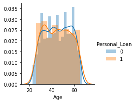

```python
sns.FacetGrid(loandata,hue="Personal_Loan").map(sns.distplot,"Age").add_legend()
```

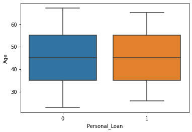

```python
sns.boxplot(x="Personal_Loan",y="Age",data=loandata)
```

Age does not seem very informative

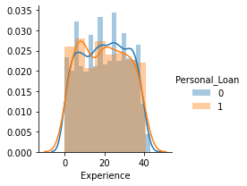

```python
sns.FacetGrid(loandata,hue="Personal_Loan").map(sns.distplot,"Experience").add_legend()
```

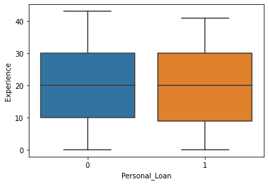

```python
sns.boxplot(x="Personal_Loan",y="Experience",data=loandata)
```

Experience does not seem very informative

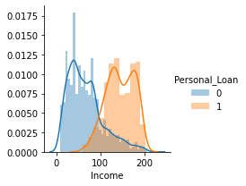

```python
sns.FacetGrid(loandata,hue="Personal_Loan").map(sns.distplot,"Income").add_legend()
```

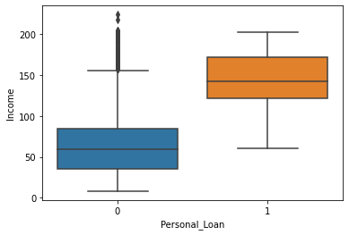

```python
sns.boxplot(x="Personal_Loan",y="Income",data=loandata)
```

Income seems to be an informative predictor

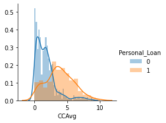

```python
sns.FacetGrid(loandata,hue="Personal_Loan").map(sns.distplot,"CCAvg").add_legend()
```

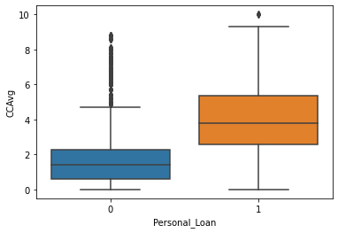

```python
sns.boxplot(x="Personal_Loan",y="CCAvg",data=loandata)
```

Credit Card average seems to be an informative predictor

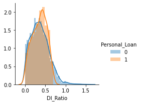

```python
sns.FacetGrid(loandata,hue="Personal_Loan").map(sns.distplot,"DI_Ratio").add_legend()
```

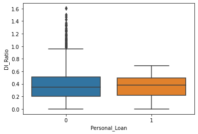

```python
sns.boxplot(x="Personal_Loan",y="DI_Ratio",data=loandata)
```

For continuous variables it appears that there is a strong relationship between the target variable and income and credit card average. I would expect that these have a stronger predictive value than age, years of professional experience or debt to income ratio.

```python
#categorical variables vs the outcome variable
loandata.info()
```

```
<class 'pandas.core.frame.DataFrame'>
RangeIndex: 5000 entries, 0 to 4999
Data columns (total 20 columns):
 #   Column              Non-Null Count  Dtype
---  ------              --------------  -----
 0   ID                  5000 non-null   int64
 1   Age                 5000 non-null   int64
 2   Experience          5000 non-null   int64
 3   Income              5000 non-null   int64
 4   ZIPCode             5000 non-null   int64
 5   Family              5000 non-null   int64
 6   CCAvg               5000 non-null   float64
 7   Education           5000 non-null   int64
 8   Mortgage            5000 non-null   int64
 9   Personal_Loan       5000 non-null   int64
 10  Securities_Account  5000 non-null   int64
 11  CD_Account          5000 non-null   int64
 12  Online              5000 non-null   int64
 13  CreditCard          5000 non-null   int64
 14  Mortgage_ind        5000 non-null   int32
 15  Monthly_Income      5000 non-null   float64
 16  Monthly_Mortgage    5000 non-null   float64
 17  DI_Ratio            5000 non-null   float64
 18  Savings_sum         5000 non-null   int64
 19  Savings_ind         5000 non-null   int64
dtypes: float64(4), int32(1), int64(15)
memory usage: 761.8 KB
```

```python
# function to plot stacked bar chart


def stacked_barplot(data, predictor, target):
    """
    Print the category counts and plot a stacked bar chart

    data: dataframe
    predictor: independent variable
    target: target variable
    """
    count = data[predictor].nunique()
    sorter = data[target].value_counts().index[-1]
    tab1 = pd.crosstab(data[predictor], data[target], margins=True).sort_values(
        by=sorter, ascending=False
    )
    print(tab1)
    print("-" * 120)
    tab = pd.crosstab(data[predictor], data[target], normalize="index").sort_values(
        by=sorter, ascending=False
    )
    tab.plot(kind="bar", stacked=True, figsize=(count + 5, 6))
    plt.legend(
        loc="lower left", frameon=False,
    )
    plt.legend(loc="upper left", bbox_to_anchor=(1, 1))
    plt.show()
```

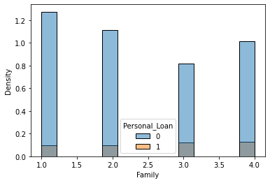

```python
sns.histplot(data=loandata,x="Family",hue="Personal_Loan",stat='density')
```